# IMPORTS: PACKAGES USED

```python
import requests
import time
import bs4
import pandas as pd
import numpy as np
import matplotlib.pyplot as plt
import seaborn as sns
from sklearn.preprocessing import MinMaxScaler
from scipy.spatial.distance import euclidean
import warnings
warnings.filterwarnings('ignore', category=FutureWarning)
```

# FUNCTIONS

## A. DATA COLLECTION FUNCTIONS

```python
def conferences():
    """
    Return dictionary of conference where
    keys are the conference ID and the
    values are the conference names
    """
    url = 'https://www.pba.ph/stats'
    response = requests.get(url).text
    soup = bs4.BeautifulSoup(response)
    time.sleep(1)

    conferences_dict = {}
    for conf in soup.select("select[id='conf'] option"):
        (conferences_dict
         .setdefault(conf['value'], conf.text))
    return conferences_dict

def player_dataframe():
    """
    Return empty dataframe where
    the columns are the headers of
    the PBA player stats table.
    Add conference name at the
    first column.
    """
    url = 'https://www.pba.ph/stats'
    response = requests.get(url).text
    soup = bs4.BeautifulSoup(response)
    time.sleep(1)

    player_data = {}
    player_data['CONFERENCE'] = []
    for i in soup.select("thead tr th"):
        player_data.setdefault(i.text, [])
    df_player = pd.DataFrame(player_data)
    return df_player

def get_player_stats(df_player, conferences_dict):
    for conf_id in conferences_dict:
        url = (f'https://www.pba.ph/stats?conf={conf_id}&team=all'
               f'&stat=sPointsAverage&type=TOT&sort=DESC')

        # GET CONFERENCE RESPONSE
        response = requests.get(url).text
        soup = bs4.BeautifulSoup(response)
        time.sleep(2)

        # GET PLAYER DATA FOR THE CONFERENCE
        players = (soup
                   .find('div', class_='col-lg-12 col-md1-2 col-sm-12 col-xs -12')
                   .find('tbody')
                   .find_all('tr'))

        conference_data = []
        for player in players:
            row = []
            row.append(conferences_dict[conf_id])
            for data in player.find_all('td'):
                row.append(data.text)
            conference_data.append(row)

        # ADD CONFERENCE DATA TO DF_PLAYER
        for i in conference_data:
            df_player.loc[len(df_player)] = i
    return df_player
```

## B. DATA PRE-PROCESSING FUNCTIONS

```python
def get_cumulative_stats(df, conferences=None):
    """
    Return cumulative player statistics and
    group per player. Drop conference columns
    """
    if conferences:
        keep_rows = df['CONFERENCE'].isin(conferences)
        df = df.loc[keep_rows]

    grouped_df = (df
                  .drop(columns=['CONFERENCE'])
                  .groupby('PLAYERS')
                  .sum(numeric_only=True))

    return grouped_df

def get_byMin_stats(df, raw_features):
    """
    Return dataframe containing
    average statistics per minute
    for each of the players
    """
    # GET IMPORTANT FEATURES
    features = [feature for feature in raw_features
        if feature not in ['GP', 'MIN']]

    # GET STATS PER MINUTE
    df_byMin = pd.DataFrame()
    df_byMin[features] = df[features].div(df['MIN'], axis=0)

    return df_byMin
```

## C. EDA FUNCTIONS

```python
def offensive_stats_distribution():
    """
    Return a plot illustrating offensive
    player statistics per 40 minutes.
    """
    plt.figure(figsize=(18, 12))

    plt.suptitle('Figure 2: Per 40 Minutes Offensive Statistics of PBA Players', fontsize=20, y=1.03)

    plt.subplot(2, 3, 1)
    sns.histplot(df_player_P40['PTS'], kde=True, color='r', edgecolor='black')
    plt.title('Figure 2A: Points Per 40 Minutes (PTS)')
    plt.xlabel('Points Made')
    plt.ylabel('Frequency')

    plt.subplot(2, 3, 2)
    sns.histplot(df_player_P40['3Pm'], kde=True, color='r', edgecolor='black')
    plt.title('Figure 2B: Three-Pointers Made Per 40 Minutes (3Pm)')
    plt.xlabel('Three-Pointers Made')
    plt.ylabel('Frequency')

    plt.subplot(2, 3, 3)
    sns.histplot(df_player_P40['oREB'], kde=True, color='r', edgecolor='black')
    plt.title('Figure 2C: Offensive Rebounds Per 40 Minutes (oREB)')
    plt.xlabel('Offensive Rebounds Made')
    plt.ylabel('Frequency')

    plt.subplot(2, 3, 4)
    sns.histplot(df_player_P40['APG'], kde=True, color='r', edgecolor='black')
    plt.title('Figure 2D: Assists Per 40 Minutes (APG)')
    plt.xlabel('Assists Made')
    plt.ylabel('Frequency')

    plt.subplot(2, 3, 5)
    sns.histplot(df_player_P40['TOV'], kde=True, color='r', edgecolor='black')
    plt.title('Figure 2E: Turnovers Per 40 Minutes (TOV)')
    plt.xlabel('Turnovers')
    plt.ylabel('Frequency')

    plt.tight_layout(rect=[0, 0.03, 1, 0.95])
    plt.show()

def defensive_stats_distribution():
    """
    Return a plot illustrating defensive
    player statistics per 40 minutes.
    """
    plt.figure(figsize=(18, 6))

    plt.suptitle('Figure 3: Defensive Statistics of PBA Players Per 40 Minutes', fontsize=20, y=1.03)

    plt.subplot(1, 3, 1)
    sns.histplot(df_player_P40['dREB'], kde=True, color='r', edgecolor='black')
    plt.title('Figure 3A: Defensive Rebounds Per 40 Minutes (dREB)')
    plt.xlabel('Defensive Rebounds Made')
    plt.ylabel('Frequency')


    plt.subplot(1, 3, 2)
    sns.histplot(df_player_P40['BLK'], kde=True, color='r', edgecolor='black')
    plt.title('Figure 3B: Blocks Per 40 Minutes (BLK)')
    plt.xlabel('Blocks Made')
    plt.ylabel('Frequency')

    plt.subplot(1, 3, 3)
    sns.histplot(df_player_P40['STL'], kde=True, color='r', edgecolor='black')
    plt.title('Figure 3C: Steals Per 40 Minutes (STL)')
    plt.xlabel('Steals Made')
    plt.ylabel('Frequency')

    plt.tight_layout()
    plt.show()

def generate_heatmap():
    """
    Generate correlation heatmap for
    for each of the player statistics
    """
    cmap = sns.diverging_palette(10, 133, l=50, s=100, n=90, as_cmap=True)
    correlation_df_player_P40 = df_player_P40.corr()

    plt.figure(figsize=(12, 10))
    sns.heatmap(correlation_df_player_P40, annot=True, cmap=cmap, fmt=".2f", center=0)
    plt.title("Figure 4: Correlation Heatmap", size=18)
    plt.xticks(size=10)  # Adjust as necessary
    plt.yticks(size=10)  # Adjust as necessary

    # Tight layout often helps with fitting everything into the figure
    plt.tight_layout()

    plt.show()
```

## D. METHOD IMPLEMENTATION FUNCTIONS

```python
def get_normalized_stats(df):
    """
    Return data frame where data
    are already normalized using
    Min-Max Scaler.
    """
    # INITIALIZE MIN-MAX SCALER
    sscaler = MinMaxScaler()

    # SCALE DATA
    scaled_data = sscaler.fit_transform(df.astype(float))
    index_list = list(df.index)
    features = df.columns
    df_normalized = pd.DataFrame(data = scaled_data,
                            columns = features,
                            index = index_list)
    return df_normalized

def get_similar_players(df, exemplar_name, threshold=0.8):
    """
    Return players that are similar to the
    exemplar given a certain threshold on
    similarity scores.
    """
    try:
        # GET EXEMPLAR DATA AND DROP ROW IN DATABASE
        exemplar = df.loc[exemplar_name]
        df_compare = df.drop(index=exemplar_name)

        # GET DISTANCES OF EXEMPLAR FROM EACH PLAYER
        distances = df_compare.apply(
            lambda row: euclidean(row, exemplar), axis=1)
        theoretical_max_distance = df.shape[1]**0.5

        # GET SIMILARITY SCORES
        similarity_scores = 1-(distances/theoretical_max_distance)
        similars = similarity_scores[similarity_scores > threshold]

        return similars.sort_values(ascending=False)
    except:
        print(
            f"Player {exemplar_name} not available for comparison. Possible typo in name or lack of data.")
        return None
```

## E. PERFORMANCE EVALUATION FUNCTIONS

```python
def performance_results(similars_list, expert_opinion_list):
    """
    Return performance metrics
    to get confusion matrix
    """
    TP = sum([i in expert_opinion_list for i in similars_list])
    FP = sum([i not in expert_opinion_list for i in similars_list])
    FN = sum([i not in similars_list for i in expert_opinion_list])
    return TP, FP, FN

def precision_recall_f(metrics):
    """
    Return precision, recall, and f-measure
    """
    TP, FP, FN = metrics
    Precision = TP / (TP+FP) ### Precision is the portion of our predictions that were true
    Recall = TP / (TP+FN) ### the portion of predictions out of the total positives
    F1_Score = 2 * (Precision*Recall) / (Precision+Recall)
    return Precision, Recall, F1_Score
```

# -- START OF TECHNICAL REPORT --

[figure not shown]

# ABSTRACT

This project utilizes Python and data mining techniques to extract insights from the Philippine Basketball Association (PBA) player data. The objective is to identify player similarities based on career statistics, which are normalized for a 40-minute rate and scaled using min-max scaling. The process involves web scraping, data aggregation, normalization, and the computation of Euclidean distances to generate a concise list of players with comparable performance profiles.

The project begins with the extraction of player statistics from the PBA website, spanning their entire careers. These statistics encompass key metrics such as points, rebounds, assists, steals, and blocks. Normalization to a 40-minute rate is applied to ensure equitable comparisons. Subsequently, min-max scaling is employed to standardize the data.

This data is then passed to the Player Similarity Retrieval System. Player similarities are determined using the Euclidean distance metric, measuring the distance between the scaled and normalized statistics. This produces a valuable list of players who share similar performance characteristics to an exemplar. The resulting list serves as a useful resource for coaches, analysts, and enthusiasts seeking to identify players with analogous playing styles.

In this project, we test the accuracy of this methodology by choosing one player, J. Fajardo, to serve as an example exemplar. This list is then compared to a list of similar players chosen by a PBA expert using human judgment. The expert's list is accepted as a source-of-truth and subsequently, the project's results are compared against this to measure accuracy via precision and recall. The precision, recall, and F1-score were 0.68, 0.60, and 0.64.

The output of the Player Similarity Retrieval System achieved moderate accuracy. In the recommendation section, possible avenues for further improvement were discussed, namely through the availability for more advanced features, advanced distance metrics, dimensionality reduction, weighted scaling, and incorporating a time-series element over player data.

# OBJECTIVES AND PURPOSE

This project showcases the application of data mining and wrangling uncover patterns in PBA player data. The compiled list of similar players offers valuable insights into player comparisons, enabling informed decisions and advancing our comprehension of player performance within the Philippine Basketball Association.

## A. PROBLEM STATEMENT

How to create a similarity retrieval tool that allows a user to pull a list of similar players based on statistics in the PBA?

## B. MOTIVATION

The PBA in the Philippines has not yet ventured into gamifying the sport through a fantasy online game, a trend that has gained immense popularity in recent times. Should the organization decide to develop such a game to engage new fans, a significant challenge lies in the fact that these potential fans may possess limited knowledge about the players, a crucial element in fantasy sports. Their familiarity may only extend to a handful of popular players. The pivotal question then becomes:  
**HOW CAN THE PBA CAPITALIZE ON THIS SITUATION WHILE UTILIZING THE PLAYER STATISTICS INFORMATION AVAILABLE ON THEIR WEBSITE?**

With the output of the project, fans can quickly find players with similar stats to any player they query. The following can be use cases:

- Future fantasy players can use this information to create their fantasy sports strategy for drafting, matchups, and player replacements.
- The PBA can utilize the similarity retrieval system to educate fans, assisting them in discovering and learning more about players to follow. Recommendations can be tailored based on their favorite players or those they are familiar with.
- Users such as fantasy sports influencers can utilize this tool to generate information to create content for the PBA (and if ever its own fantasy sports application).

# PROJECT OVERVIEW

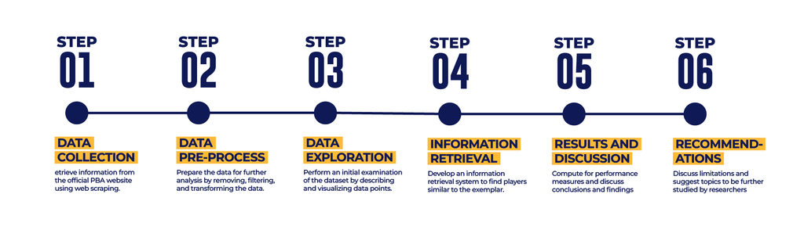

**Figure 1.** Project Overview Flowchart

**Table 1.** Project Pipeline

[output not shown]

The project pipeline offers a thorough overview of the team's approach to the entire project, spanning from data retrieval to recommending additional studies. It furnishes an in-depth explanation of each step, encompassing sub-steps within each to ensure a comprehensive understanding of the workflow (Refer to Table 1).

# DATA COLLECTION

## A. DATA SOURCE

The Data Source used for this project is All Player Statistics available for all conferences listed in the PBA Stats page, web scraped from PBA's Stats page containing Player Statistics *(Philippine Basketball Association [PBA], 2023)*.

The Player Statistics table contains three filtering options: one for different PBA Conferences dating back from the 2023-24 PBA Commissioner's Cup until the 2017 PBA Governor's Cup, one for selecting per PBA team or All PBA teams combined, and the last one to view the statistics data as Average stats or as Total stats form.

### Player Statistics Data

The website page contains tabular data for players from the past 15 championship cups (2017-2024), 13 teams (‘All Teams’ and the 12 individual teams in the league). The player statistics data is available in 2 types of views(Average and Total).

## B. METADATA / DATA DESCRIPTION

**Table 2.** Dataset Metadata

| Feature Name | Feature Description | Sample Record | Data Type |
| --- | --- | --- | --- |
| CONFERENCE | Tournaments within a PBA season | 2023-24 PBA Commissioner's Cup | String |
| PLAYERS | Player name with First name (Abbreviated) and Last name | Q. Miller | String |
| GP | Games Played in a Conference or Career | 5 | Integer |
| MIN | Total Minutes Played for a Conference or Career | 120.96 | Float |
| FGm | The amount of two point and three point field goals a player made | 10 | Float |
| FGa | The amount of two point and three point field goals a player attempted | 18 | Float |
| 3Pm | The amount of three point field goals a player made | 15 | Integer |
| 3Pa | The amount of three point field goals a player attempted | 40 | Integer |
| FTm | The amount of free throws a player made | 8 | Float |
| FTa | The amount of free throws a player attempted | 10 | Float |
| APG | The amount of (assists) passes a player made to a teammate that leads directly to a field goal | 10 | Integer |
| STL | The amount of steals by a player, when successfully intercepting an opponent's pass or dribbles, gaining possession of the ball | 2 | Integer |
| BLK | The amount of blocks by a player, when deflecting or stopping an opponent field goal attempt | 3 | Integer |
| oREB | The amount of offensive rebounds when a player gains control of the ball after a missed field goal by a player's own team | 8 | Integer |
| dREB | The amount of offensive rebounds when a player gains control of the ball after a missed field goal by an opponent | 9 | Integer |
| PF | Personal Fouls is the number of violations by committed by a player involving illegal physical contact or rule infractions | 6 | Integer |
| TOV | The number of times a player loses possession of the ball to the opposing team | 4 | Integer |
| +/- | The plus-minus (+/−) statistic in basketball measures the point differential when a player is on the court | +14 | Integer |
| PTS | The amount of points the player scored in the game through field goals, and 3-points | 150 | Float |

The columns below are categories that will be utilized to calculate the similarity for each player in the table: (Refer to Table 3)

**Table 3.** Player Statistics Categories to be Used

| Feature Name | Feature Description | Sample Record | Data Type |
| --- | --- | --- | --- |
| PTS | The amount of points the player scored in the game through field goals, and 3-points | 150 | Float |
| 3Pm | The amount of three point field goals a player made | 15 | Integer |
| APG | The amount of (assists) passes a player made to a teammate that leads directly to a field goal | 10 | Integer |
| STL | The amount of steals by a player, when successfully intercepting an opponent's pass or dribbles, gaining possession of the ball | 2 | Integer |
| BLK | The amount of blocks by a player, when deflecting or stopping an opponent field goal attempt | 3 | Integer |
| oREB | The amount of offensive rebounds when a player gains control of the ball after a missed field goal by a player's own team | 8 | Integer |
| dREB | The amount of offensive rebounds when a player gains control of the ball after a missed field goal by an opponent | 9 | Integer |
| TOV | The number of times a player loses possession of the ball to the opposing team | 4 | Integer |

# DATA PRE-PROCESSING

## A. LOAD DATA

### A.1 GET CONFERENCES

This section uses the `conferences()` data collection function to get a dictionary list of the Conference Names listed in the PBA Stats Website.

```python
conference_data = conferences()
df_conference = pd.DataFrame(list(conference_data.items()),
                             columns=['Conference ID',
                                      'Conference Name'])
print('CONFERENCES AVAILABLE:')
display(df_conference.head())
```

```
CONFERENCES AVAILABLE:
```

|  | Conference ID | Conference Name |
| --- | --- | --- |
| 0 | 37410 | 2023-24 PBA Commissioner's Cup |
| 1 | 35979 | 2023 PBA On Tour |
| 2 | 35383 | 47th Season Governors Cup |
| 3 | 34696 | 47th Season Commissioner's Cup |
| 4 | 33821 | 47th Season Philippine Cup |

### A.2 INITIALIZE PLAYER DATAFRAME

This section uses the `player_dataframe()` data collection function to get the dataframe with only the headers from PBA Stats Website.

```python
df_player = player_dataframe()
print('PLAYER STATISTICS DATAFRAME:')
display(df_player)
```

```
PLAYER STATISTICS DATAFRAME:
```

|  | CONFERENCE | PLAYERS |  | GP | MIN | FGm | FGa | FG% | 3Pm | 3Pa | ... | APG | STL | BLK | oREB | dREB | REB | PF | TOV | +/- | PTS |
| --- | --- | --- | --- | --- | --- | --- | --- | --- | --- | --- | --- | --- | --- | --- | --- | --- | --- | --- | --- | --- | --- |

0 rows × 24 columns

### A.3 GET PLAYER STATISTICS

This section uses the `get_player_stats` data collection function to get all the player stats (totals) for every conference from PBA Stats Website.

```python
df_player = get_player_stats(df_player, conference_data)
print('RAW PLAYER STATISTICS:')
display(df_player)
```

```
RAW PLAYER STATISTICS:
```

|  | CONFERENCE | PLAYERS |  | GP | MIN | FGm | FGa | FG% | 3Pm | 3Pa | ... | APG | STL | BLK | oREB | dREB | REB | PF | TOV | +/- | PTS |
| --- | --- | --- | --- | --- | --- | --- | --- | --- | --- | --- | --- | --- | --- | --- | --- | --- | --- | --- | --- | --- | --- |
| 0 | 2023-24 PBA Commissioner's Cup | Q. Miller |  | 1 | 41.05 | 14 | 26 | 54% | 3 | 12 | ... | 1 | 4 | 2 | 2 | 12 | 14 | 2 | 3 | 5 | 37 |
| 1 | 2023-24 PBA Commissioner's Cup | T. Robinson |  | 4 | 149.22 | 51 | 89 | 57% | 1 | 4 | ... | 14 | 7 | 7 | 12 | 41 | 53 | 16 | 23 | -4 | 138 |
| 2 | 2023-24 PBA Commissioner's Cup | T. Bey |  | 4 | 155.35 | 44 | 80 | 55% | 5 | 19 | ... | 7 | 12 | 4 | 19 | 35 | 54 | 10 | 11 | 75 | 119 |
| 3 | 2023-24 PBA Commissioner's Cup | T. Bishop Jr. |  | 2 | 88.23 | 17 | 42 | 40% | 2 | 6 | ... | 6 | 3 | 3 | 11 | 13 | 24 | 6 | 7 | 9 | 55 |
| 4 | 2023-24 PBA Commissioner's Cup | V. Jois |  | 4 | 166.72 | 47 | 79 | 59% | 4 | 9 | ... | 16 | 6 | 7 | 21 | 37 | 58 | 12 | 16 | -17 | 109 |
| ... | ... | ... | ... | ... | ... | ... | ... | ... | ... | ... | ... | ... | ... | ... | ... | ... | ... | ... | ... | ... | ... |
| 5194 | 2017 PBA Governors Cup | R. Celiz |  | 5 | 10.77 | 0 | 2 | 0% | 0 | 0 | ... | 1 | 0 | 0 | 0 | 1 | 1 | 2 | 0 | -14 | 0 |
| 5195 | 2017 PBA Governors Cup | C. Ellis |  | 0 | 0.00 | 0 | 0 | 0% | 0 | 0 | ... | 0 | 0 | 0 | 0 | 0 | 0 | 0 | 0 | 0 | 0 |
| 5196 | 2017 PBA Governors Cup | M. Cardona |  | 0 | 0.00 | 0 | 0 | 0% | 0 | 0 | ... | 0 | 0 | 0 | 0 | 0 | 0 | 0 | 0 | 0 | 0 |
| 5197 | 2017 PBA Governors Cup | J. Thomas |  | 0 | 0.00 | 0 | 0 | 0% | 0 | 0 | ... | 0 | 0 | 0 | 0 | 0 | 0 | 0 | 0 | 0 | 0 |
| 5198 | 2017 PBA Governors Cup | M. Blakely |  | 0 | 0.00 | 0 | 0 | 0% | 0 | 0 | ... | 0 | 0 | 0 | 0 | 0 | 0 | 0 | 0 | 0 | 0 |

5199 rows × 24 columns

## B. DATA CLEANING / PREPARATION

### B.1 FORMAT DATA COLUMNS

This section formats the data columns by stripping each column name for whitespaces for data alignment and string comparison.

```python
df_player.columns = [col.strip() for col in df_player.columns]
print('COLUMN NAMES:')
print(df_player.columns)
```

```
COLUMN NAMES:
Index(['CONFERENCE', 'PLAYERS', '', 'GP', 'MIN', 'FGm', 'FGa', 'FG%', '3Pm',
       '3Pa', '3P%', 'FTm', 'FTa', 'FT%', 'APG', 'STL', 'BLK', 'oREB', 'dREB',
       'REB', 'PF', 'TOV', '+/-', 'PTS'],
      dtype='object')
```

### B.2 DROP BLANK COLUMN AND CONVERT FEATURES TO NUMERIC

This function drops the blank column in the dataframe that contained the Team Logo of the Players' respective teams.

This also converts features to be used into **numeric format** for easier data manipulation.

```python
col_list = ['PLAYERS', 'CONFERENCE', 'GP', 'MIN', 'PTS', 'REB', 'oREB',
            'dREB', 'APG', 'BLK', 'STL', 'TOV',  'FGm', 'FGa', '3Pm', '3Pa']
raw_features = ['GP', 'MIN', 'PTS', 'oREB',
                'dREB', 'APG', 'BLK', 'STL', 'TOV', '3Pm']

# DROP BLANK COLUMN
df_subset = df_player.loc[:, col_list]

# CONVERT RAW FEATURES TO NUMERIC
df_subset[raw_features] = (df_subset[raw_features]
                           .apply(pd.to_numeric,
                                  errors='coerce'))
df_player = df_subset
print('PREVIEW OF WITH BLANK COLUMN DROPPED AND FEATURES TO NUMERIC:')
display(df_player)
```

```
PREVIEW OF WITH BLANK COLUMN DROPPED AND FEATURES TO NUMERIC:
```

|  | PLAYERS | CONFERENCE | GP | MIN | PTS | REB | oREB | dREB | APG | BLK | STL | TOV | FGm | FGa | 3Pm | 3Pa |
| --- | --- | --- | --- | --- | --- | --- | --- | --- | --- | --- | --- | --- | --- | --- | --- | --- |
| 0 | Q. Miller | 2023-24 PBA Commissioner's Cup | 1 | 41.05 | 37 | 14 | 2 | 12 | 1 | 2 | 4 | 3 | 14 | 26 | 3 | 12 |
| 1 | T. Robinson | 2023-24 PBA Commissioner's Cup | 4 | 149.22 | 138 | 53 | 12 | 41 | 14 | 7 | 7 | 23 | 51 | 89 | 1 | 4 |
| 2 | T. Bey | 2023-24 PBA Commissioner's Cup | 4 | 155.35 | 119 | 54 | 19 | 35 | 7 | 4 | 12 | 11 | 44 | 80 | 5 | 19 |
| 3 | T. Bishop Jr. | 2023-24 PBA Commissioner's Cup | 2 | 88.23 | 55 | 24 | 11 | 13 | 6 | 3 | 3 | 7 | 17 | 42 | 2 | 6 |
| 4 | V. Jois | 2023-24 PBA Commissioner's Cup | 4 | 166.72 | 109 | 58 | 21 | 37 | 16 | 7 | 6 | 16 | 47 | 79 | 4 | 9 |
| ... | ... | ... | ... | ... | ... | ... | ... | ... | ... | ... | ... | ... | ... | ... | ... | ... |
| 5194 | R. Celiz | 2017 PBA Governors Cup | 5 | 10.77 | 0 | 1 | 0 | 1 | 1 | 0 | 0 | 0 | 0 | 2 | 0 | 0 |
| 5195 | C. Ellis | 2017 PBA Governors Cup | 0 | 0.00 | 0 | 0 | 0 | 0 | 0 | 0 | 0 | 0 | 0 | 0 | 0 | 0 |
| 5196 | M. Cardona | 2017 PBA Governors Cup | 0 | 0.00 | 0 | 0 | 0 | 0 | 0 | 0 | 0 | 0 | 0 | 0 | 0 | 0 |
| 5197 | J. Thomas | 2017 PBA Governors Cup | 0 | 0.00 | 0 | 0 | 0 | 0 | 0 | 0 | 0 | 0 | 0 | 0 | 0 | 0 |
| 5198 | M. Blakely | 2017 PBA Governors Cup | 0 | 0.00 | 0 | 0 | 0 | 0 | 0 | 0 | 0 | 0 | 0 | 0 | 0 | 0 |

5199 rows × 16 columns

### B.3 REMOVE DUPLICATES

This Removes Duplicate Entries of Players with similar Conference names, Player names and Games Played.

There are added additional categories for filters **FGm, FGa, 3Pm, 3Pa, REB** to account for rare situations:

1. Player traded mid-conference and accumulates the same number of games played and/or minutes
2. Conference name changes without a year identifier

*Minutes category cannot be used as a filter because of dirty minutes data (ex. duplicate entries listed as 119.09 vs 119.10)*

```python
# SHOW ORIGINAL ROW COUNT
print(f"Original Row Count: {len(df_player)}")

# DROP DUPLICATES
dummy = df_player
df_player.sort_values(by='MIN', ascending=False, inplace=True)
df_player = df_player.drop_duplicates(subset=['CONFERENCE', 'PLAYERS',
                                              'GP', 'FGm', 'FGa', '3Pm',
                                              '3Pa', 'REB'], keep='first')
print(f"Duplicates dropped: {len(dummy)-len(df_player)}\n")
print('PREVIEW WITH DUPLICATES REMOVED:')
display(df_player)
```

```
Original Row Count: 5199
Duplicates dropped: 1789

PREVIEW WITH DUPLICATES REMOVED:
```

|  | PLAYERS | CONFERENCE | GP | MIN | PTS | REB | oREB | dREB | APG | BLK | STL | TOV | FGm | FGa | 3Pm | 3Pa |
| --- | --- | --- | --- | --- | --- | --- | --- | --- | --- | --- | --- | --- | --- | --- | --- | --- |
| 1121 | E. Clark | 47th Season Commissioner's Cup | 13 | 542.13 | 420 | 207 | 40 | 167 | 52 | 31 | 17 | 44 | 163 | 310 | 21 | 60 |
| 2259 | K. McDaniels | 2019 PBA Governors’ Cup | 11 | 510.40 | 408 | 153 | 36 | 117 | 57 | 38 | 18 | 56 | 147 | 273 | 35 | 90 |
| 2485 | J. Brownlee | 2019 PBA Commissioner's Cup | 11 | 501.48 | 395 | 150 | 16 | 134 | 63 | 24 | 29 | 32 | 151 | 276 | 37 | 91 |
| 1125 | J. Brownlee | 47th Season Commissioner's Cup | 12 | 495.07 | 338 | 126 | 27 | 99 | 86 | 14 | 13 | 33 | 120 | 257 | 28 | 91 |
| 1130 | R. Bolick | 47th Season Commissioner's Cup | 12 | 494.92 | 260 | 54 | 10 | 44 | 78 | 0 | 7 | 28 | 92 | 224 | 27 | 95 |
| ... | ... | ... | ... | ... | ... | ... | ... | ... | ... | ... | ... | ... | ... | ... | ... | ... |
| 4111 | N. Pinto | 2018 PBA Philippine Cup | 11 | 0.00 | 38 | 40 | 15 | 25 | 39 | 1 | 15 | 12 | 14 | 50 | 3 | 11 |
| 4108 | D. Ababou | 2018 PBA Philippine Cup | 10 | 0.00 | 35 | 4 | 1 | 3 | 2 | 2 | 2 | 4 | 13 | 31 | 2 | 11 |
| 4107 | C. Lastimosa | 2018 PBA Philippine Cup | 5 | 0.00 | 18 | 4 | 2 | 2 | 5 | 0 | 2 | 5 | 7 | 30 | 2 | 9 |
| 4106 | M. Baracael | 2018 PBA Philippine Cup | 10 | 0.00 | 36 | 17 | 7 | 10 | 5 | 0 | 1 | 6 | 14 | 28 | 6 | 15 |
| 5198 | M. Blakely | 2017 PBA Governors Cup | 0 | 0.00 | 0 | 0 | 0 | 0 | 0 | 0 | 0 | 0 | 0 | 0 | 0 | 0 |

3410 rows × 16 columns

### B.4 DROP PLAYERS WITH NO GAMES PLAYED (GP)

This section eliminates players who have not participated in any games (0 Games Played) from the analysis due to their lack of significance.

```python
# DROP PLAYERS WITH 0 GAMES PLAYED
dummy2 = df_player
df_player = df_player.drop(
    df_player[(df_player['GP'] == 0) | (df_player['GP'].isna())].index)
print(f"Players w/ 0 Games dropped: {len(dummy2) - len(df_player)}\n")
print('PREVIEW WITH PLAYERS WITH 0 GAMES DROPPED:')
display(df_player)
```

```
Players w/ 0 Games dropped: 836

PREVIEW WITH PLAYERS WITH 0 GAMES DROPPED:
```

|  | PLAYERS | CONFERENCE | GP | MIN | PTS | REB | oREB | dREB | APG | BLK | STL | TOV | FGm | FGa | 3Pm | 3Pa |
| --- | --- | --- | --- | --- | --- | --- | --- | --- | --- | --- | --- | --- | --- | --- | --- | --- |
| 1121 | E. Clark | 47th Season Commissioner's Cup | 13 | 542.13 | 420 | 207 | 40 | 167 | 52 | 31 | 17 | 44 | 163 | 310 | 21 | 60 |
| 2259 | K. McDaniels | 2019 PBA Governors’ Cup | 11 | 510.40 | 408 | 153 | 36 | 117 | 57 | 38 | 18 | 56 | 147 | 273 | 35 | 90 |
| 2485 | J. Brownlee | 2019 PBA Commissioner's Cup | 11 | 501.48 | 395 | 150 | 16 | 134 | 63 | 24 | 29 | 32 | 151 | 276 | 37 | 91 |
| 1125 | J. Brownlee | 47th Season Commissioner's Cup | 12 | 495.07 | 338 | 126 | 27 | 99 | 86 | 14 | 13 | 33 | 120 | 257 | 28 | 91 |
| 1130 | R. Bolick | 47th Season Commissioner's Cup | 12 | 494.92 | 260 | 54 | 10 | 44 | 78 | 0 | 7 | 28 | 92 | 224 | 27 | 95 |
| ... | ... | ... | ... | ... | ... | ... | ... | ... | ... | ... | ... | ... | ... | ... | ... | ... |
| 4112 | J. Ballesteros | 2018 PBA Philippine Cup | 10 | 0.00 | 32 | 74 | 26 | 48 | 2 | 9 | 1 | 10 | 12 | 21 | 0 | 0 |
| 4111 | N. Pinto | 2018 PBA Philippine Cup | 11 | 0.00 | 38 | 40 | 15 | 25 | 39 | 1 | 15 | 12 | 14 | 50 | 3 | 11 |
| 4108 | D. Ababou | 2018 PBA Philippine Cup | 10 | 0.00 | 35 | 4 | 1 | 3 | 2 | 2 | 2 | 4 | 13 | 31 | 2 | 11 |
| 4107 | C. Lastimosa | 2018 PBA Philippine Cup | 5 | 0.00 | 18 | 4 | 2 | 2 | 5 | 0 | 2 | 5 | 7 | 30 | 2 | 9 |
| 4106 | M. Baracael | 2018 PBA Philippine Cup | 10 | 0.00 | 36 | 17 | 7 | 10 | 5 | 0 | 1 | 6 | 14 | 28 | 6 | 15 |

2574 rows × 16 columns

### B.5 GET CUMULATIVE STATISTICS PER PLAYER

This section utilizes the `get_cumulative_stats` pre-processing function to compute the total career statistics for each player. This function aggregates individual performance metrics (selected features) across all available data, resulting in a comprehensive representation of each player's career statistics.

```python
# GET CUMULATIVE STATS PER PLAYER
df_player = get_cumulative_stats(df_player, conferences=None)
print('PREVIEW OF CUMULATIVE PLAYER STATISTICS:')
display(df_player)
```

```
PREVIEW OF CUMULATIVE PLAYER STATISTICS:
```

| PLAYERS | GP | MIN | PTS | oREB | dREB | APG | BLK | STL | TOV | 3Pm |
| --- | --- | --- | --- | --- | --- | --- | --- | --- | --- | --- |
| A. Aban | 1 | 4.33 | 2 | 0 | 0 | 1 | 0 | 0 | 1 | 0 |
| A. Asistio | 64 | 1140.74 | 494 | 16 | 83 | 111 | 0 | 24 | 51 | 117 |
| A. Barroca | 159 | 4287.17 | 1837 | 114 | 400 | 707 | 16 | 254 | 336 | 175 |
| A. Cabagnot | 92 | 2697.83 | 1231 | 70 | 347 | 417 | 14 | 90 | 161 | 112 |
| A. Capobres | 3 | 10.32 | 0 | 0 | 3 | 1 | 0 | 1 | 0 | 0 |
| ... | ... | ... | ... | ... | ... | ... | ... | ... | ... | ... |
| W. Wilson | 54 | 668.50 | 202 | 71 | 114 | 54 | 11 | 26 | 50 | 10 |
| Y. Liang | 11 | 102.65 | 20 | 2 | 15 | 9 | 0 | 4 | 5 | 3 |
| Y. Taha | 77 | 1041.10 | 369 | 106 | 234 | 86 | 38 | 24 | 106 | 1 |
| Y. de Ocampo | 17 | 43.23 | 43 | 12 | 24 | 4 | 4 | 0 | 7 | 6 |
| Z. Zhang | 3 | 14.13 | 9 | 3 | 3 | 0 | 0 | 1 | 2 | 0 |

481 rows × 10 columns

### B.6 FILTER OUT PLAYERS WITH LESS THAN TOTAL MINUTES PLAYED CUTOFF

This section filters out players by setting **'300' total minutes** as a threshold to be more representative of a player's true performance and contribution to the team, and ensure the analysis will have more accurate results.

```python
# SET MINIMUM CUTOFF IN TOTAL MINUTES PLAYED
min_cutoff = 300

# DROP PLAYERS THAT DO NOT MEET CUTOFF
df_player = (df_player.loc[df_player.MIN >= min_cutoff])

# DISPLAY OUTPUT
print('PREVIEW WITHOUT PLAYERS THAT DO NEET MEET THE TOTAL MINUTES CUTOFF')
display(df_player)
```

```
PREVIEW WITHOUT PLAYERS THAT DO NEET MEET THE TOTAL MINUTES CUTOFF
```

| PLAYERS | GP | MIN | PTS | oREB | dREB | APG | BLK | STL | TOV | 3Pm |
| --- | --- | --- | --- | --- | --- | --- | --- | --- | --- | --- |
| A. Asistio | 64 | 1140.74 | 494 | 16 | 83 | 111 | 0 | 24 | 51 | 117 |
| A. Barroca | 159 | 4287.17 | 1837 | 114 | 400 | 707 | 16 | 254 | 336 | 175 |
| A. Cabagnot | 92 | 2697.83 | 1231 | 70 | 347 | 417 | 14 | 90 | 161 | 112 |
| A. Caracut | 68 | 1339.67 | 529 | 35 | 105 | 195 | 1 | 26 | 73 | 73 |
| A. Caram | 134 | 1773.31 | 650 | 29 | 104 | 192 | 4 | 49 | 81 | 60 |
| ... | ... | ... | ... | ... | ... | ... | ... | ... | ... | ... |
| W. Castro | 133 | 3275.95 | 1808 | 96 | 444 | 666 | 55 | 182 | 291 | 172 |
| W. Selden Jr. | 7 | 311.87 | 223 | 9 | 37 | 47 | 5 | 17 | 27 | 21 |
| W. Walker | 24 | 939.71 | 563 | 43 | 288 | 121 | 29 | 53 | 70 | 60 |
| W. Wilson | 54 | 668.50 | 202 | 71 | 114 | 54 | 11 | 26 | 50 | 10 |
| Y. Taha | 77 | 1041.10 | 369 | 106 | 234 | 86 | 38 | 24 | 106 | 1 |

263 rows × 10 columns

### B.7 GET AVERAGE STATISTICS PER MINUTE FOR EACH PLAYER

This section utilizes `get_byMin_stats()` pre-processing function to get the average stats per minute of each player.

```python
# GET AVERAGE STATISTICS PER MINUTE FOR EACH PLAYER
df_player_clean = get_byMin_stats(df_player, raw_features)

# DISPLAY OUTPUT
print('PREVIEW OF AVERAGE PLAYER STATISTICS PER MINUTE')
display(df_player_clean)
```

```
PREVIEW OF AVERAGE PLAYER STATISTICS PER MINUTE
```

| PLAYERS | PTS | oREB | dREB | APG | BLK | STL | TOV | 3Pm |
| --- | --- | --- | --- | --- | --- | --- | --- | --- |
| A. Asistio | 0.433052 | 0.014026 | 0.072760 | 0.097305 | 0.000000 | 0.021039 | 0.044708 | 0.102565 |
| A. Barroca | 0.428488 | 0.026591 | 0.093302 | 0.164911 | 0.003732 | 0.059247 | 0.078373 | 0.040819 |
| A. Cabagnot | 0.456293 | 0.025947 | 0.128622 | 0.154569 | 0.005189 | 0.033360 | 0.059678 | 0.041515 |
| A. Caracut | 0.394873 | 0.026126 | 0.078378 | 0.145558 | 0.000746 | 0.019408 | 0.054491 | 0.054491 |
| A. Caram | 0.366546 | 0.016354 | 0.058647 | 0.108272 | 0.002256 | 0.027632 | 0.045677 | 0.033835 |
| ... | ... | ... | ... | ... | ... | ... | ... | ... |
| W. Castro | 0.551901 | 0.029304 | 0.135533 | 0.203300 | 0.016789 | 0.055556 | 0.088829 | 0.052504 |
| W. Selden Jr. | 0.715042 | 0.028858 | 0.118639 | 0.150704 | 0.016032 | 0.054510 | 0.086575 | 0.067336 |
| W. Walker | 0.599121 | 0.045759 | 0.306478 | 0.128763 | 0.030861 | 0.056400 | 0.074491 | 0.063849 |
| W. Wilson | 0.302169 | 0.106208 | 0.170531 | 0.080778 | 0.016455 | 0.038893 | 0.074794 | 0.014959 |
| Y. Taha | 0.354433 | 0.101815 | 0.224762 | 0.082605 | 0.036500 | 0.023053 | 0.101815 | 0.000961 |

263 rows × 8 columns

# EXPLORATORY DATA ANALYSIS

## A. GET PER 40 MINUTES STATISTICS FOR ANALYSIS

Exploratory Data Analysis (EDA) of the provided basketball players' performance statistics reveals a multi-faceted view of their on-court contributions. When we delve into their player abilities using the per 40 minutes statistics, we look to explore possible patterns in player data behavior using visualization techniques such as histogram and bar graph.

*Note that the 40 min statistics does not change any of the analysis results as everything gets normalized and scaled, it is purely for improved interpretability.

```python
# GET PER 40 MINUTES STATISTICS FOR EACH PLAYER
df_player_P40 = df_player_clean * 40

print('PREVIEW OF PER 40 MINUTE PLAYER STATISTICS:')
display(df_player_P40)
```

```
PREVIEW OF PER 40 MINUTE PLAYER STATISTICS:
```

| PLAYERS | PTS | oREB | dREB | APG | BLK | STL | TOV | 3Pm |
| --- | --- | --- | --- | --- | --- | --- | --- | --- |
| A. Asistio | 17.322089 | 0.561039 | 2.910392 | 3.892210 | 0.000000 | 0.841559 | 1.788313 | 4.102600 |
| A. Barroca | 17.139512 | 1.063639 | 3.732066 | 6.596426 | 0.149283 | 2.369862 | 3.134935 | 1.632779 |
| A. Cabagnot | 18.251706 | 1.037871 | 5.144876 | 6.182747 | 0.207574 | 1.334406 | 2.387104 | 1.660594 |
| A. Caracut | 15.794935 | 1.045033 | 3.135100 | 5.822329 | 0.029858 | 0.776311 | 2.179641 | 2.179641 |
| A. Caram | 14.661847 | 0.654144 | 2.345896 | 4.330884 | 0.090227 | 1.105278 | 1.827092 | 1.353401 |
| ... | ... | ... | ... | ... | ... | ... | ... | ... |
| W. Castro | 22.076039 | 1.172179 | 5.421328 | 8.131992 | 0.671561 | 2.222256 | 3.553168 | 2.100154 |
| W. Selden Jr. | 28.601661 | 1.154327 | 4.745567 | 6.028153 | 0.641293 | 2.180396 | 3.462981 | 2.693430 |
| W. Walker | 23.964840 | 1.830352 | 12.259101 | 5.150525 | 1.234423 | 2.256015 | 2.979643 | 2.553979 |
| W. Wilson | 12.086761 | 4.248317 | 6.821242 | 3.231114 | 0.658190 | 1.555722 | 2.991773 | 0.598355 |
| Y. Taha | 14.177312 | 4.072616 | 8.990491 | 3.304197 | 1.459994 | 0.922102 | 4.072616 | 0.038421 |

263 rows × 8 columns

## B. EXPLORATORY DATA ANALYSIS

### B.1 Per 40 Minutes Offense Statistics of PBA Players

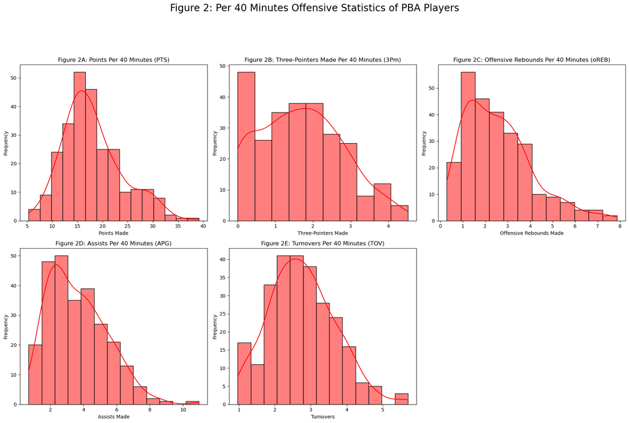

```python
# PLOT OFFENSIVE STATS
offensive_stats_distribution()
```

**Figure 2.** Offensive Statistics of PBA Players Per 40 Minutes

Collectively, these histograms offer a nuanced perspective on offensive dynamics, with each statistical measure providing insight into various components of offensive contribution, ranging from scoring and facilitation of the management of possession. (Refer to Figure 2)

The distribution of points per 40 minutes (PTS) adopts a normal distribution with a mean at 18 points, indicating a propensity for high-scoring outcomes within the league. Notably, a subset of players frequently exceed a 20-point threshold, signifying an upper tier of offensive performance (Refer to Figure 2A).

The three-pointers made (3Pm) statistic illustrates an average of 1.7, with a distribution tail that extends to and beyond four successful shots per 40 minutes. This trend indicates a strategic evolution towards a perimeter-oriented offense, underscoring the increasing valuation of long-range scoring capabilities (Refer to 2B).

The offensive rebounding (oREB) metric, with a mean of 2.6, demonstrates a steady acquisition of additional scoring opportunities and a critical element in sustaining offensive momentum (Refer to Figure 2C).

Analyzing assists per 40 minutes (APG), the distribution skews towards lower values with a mean of 3.6, yet acknowledges the existence of elite facilitators who average six assists or more (Refer to Figure 2D).

Turnover rates (TOV) average at 2.8, with their distribution reflecting the dual-edged nature of offensive aggression (Refer to Figure).

### B.2 Per 40 Minutes Defensive Statistics of PBA Players

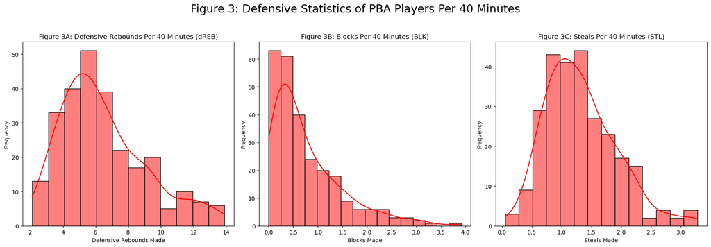

```python
# PLOT DEFENSIVE STATS
defensive_stats_distribution()
```

**Figure 3.** Defensive Statistics of PBA Players Per 40 Minutes

The histograms of PBA players' defensive statistics per 40 minutes provide a clear visualization of their defensive impact.

Defensive rebounds (dREB) average at 6.5, demonstrating the significant role players play in securing the ball post-opposition shots, a fundamental part of a solid defense (Refer to Figure 3A).

Blocks (BLK) average at 0.77, indicating the crucial timing and judgment required to effectively protect the rim. Players excelling in this metric not only prevent scoring but can also influence the offensive approach of their opponents (Refer to Figure 3B).

Steals (STL), with an average of 1.3, represent the strategic foresight and quick execution necessary for turning defense into offense. This metric highlights players' ability to create fast-break opportunities and contribute to their team's momentum (Refer to Figure 3C).

In essence, these defensive metrics collectively showcase the diverse defensive skills in the PBA, from rebounding to shot-blocking and stealing, each underpinning the overall defensive strategy vital for a team's success.

### B.3 Correlation Heatmap of Per 40 Minutes Player Statistics

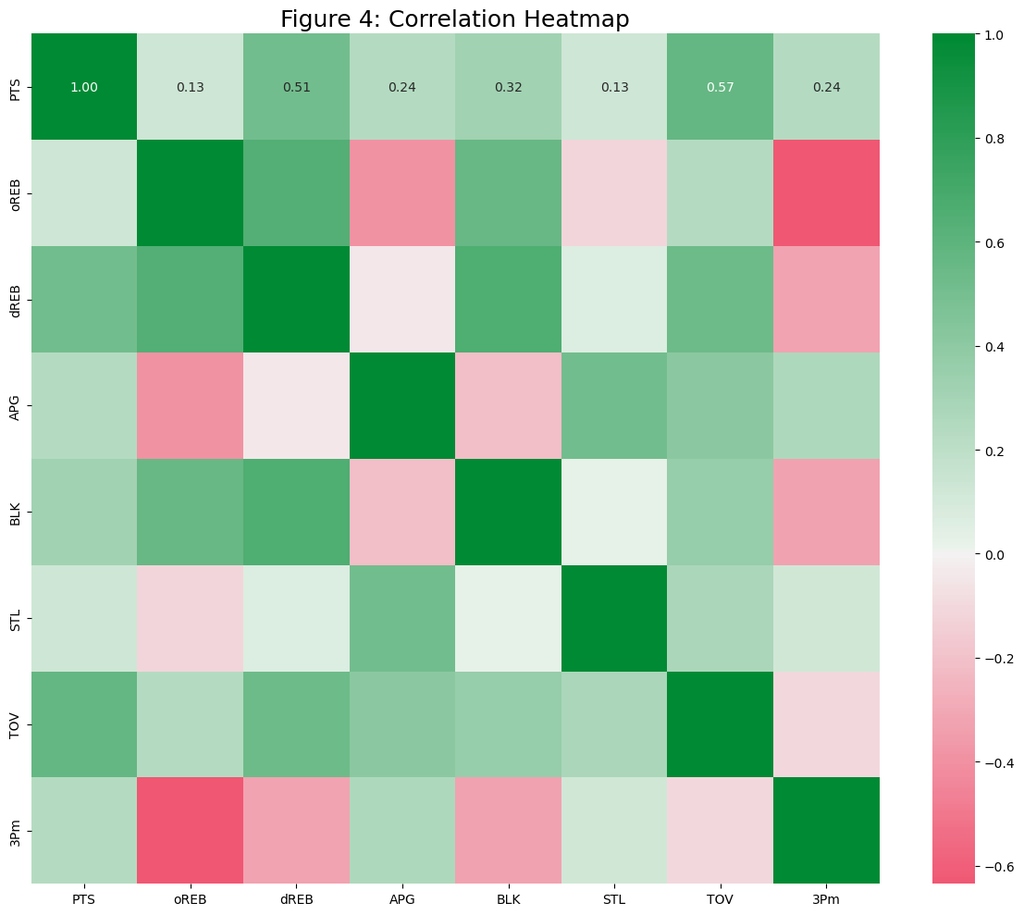

```python
# PLOT HEATMAP
generate_heatmap()
```

**Figure 4.** Correlation Heatmap of Per 40 Minutes Player Statistics

As we delve into the analytical heart of basketball, the heatmap unfurls a story told in numbers, revealing the relationships between various facets of on-court performance. The heatmap's hues, ranging from the fervent reds to the contemplative greens, serve as a guide to understanding these intricate connections.

Playmakers, reflected in the assists per game (APG) statistics, exhibit a 0.51 correlation with steals (STL).

The most profound tale told by our heatmap is one of relentless pursuit, as depicted by the 0.65 correlation between offensive (oREB) and defensive rebounds (dREB). This figure represents the grit and hustle of those who command the boards (Refer to Figure 4).

# METHODOLOGY

## A. METHOD OVERVIEW AND DISCUSSION

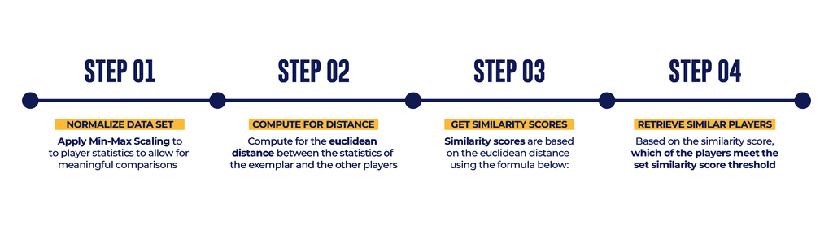

**Figure 5.** Methodology Flowchart

## B. METHOD IMPLEMETATION: INFORMATION RETRIEVAL

### B.1 NORMALIZATION: MIN-MAX SCALING

Min-max scaling was crucial for the performance metrics of PBA players because it is essential for an unbiased Euclidean distance calculation. Euclidean distance relies on the relative magnitudes of variables, and without scaling, metrics with naturally larger ranges could dominate the similarity calculation. Scaling ensures that all metrics have the same weight in the distance computation, preventing one metric from unduly influencing the player similarity results and allowing for more meaningful comparisons based on the entire set of performance metrics.

```python
# SCALE DATA USING MIN-MAX SCALER
df_player_normalized = get_normalized_stats(df_player_clean)

# DESCRIBE DATA
print('DESCRIBED PLAYER STATISTICS AFTER NORMALIZATION:')
display(df_player_normalized.describe())
print('\n')

# DISPLAY OUTPUT DATA
print('PREVIEW OF NORMALIZED PLAYER STATISTICS (MIN-MAX SCALER):')
display(df_player_normalized)
```

```
DESCRIBED PLAYER STATISTICS AFTER NORMALIZATION:
```

|  | PTS | oREB | dREB | APG | BLK | STL | TOV | 3Pm |
| --- | --- | --- | --- | --- | --- | --- | --- | --- |
| count | 263.000000 | 263.000000 | 263.000000 | 263.000000 | 263.000000 | 263.000000 | 263.000000 | 263.000000 |
| mean | 0.375394 | 0.302370 | 0.369954 | 0.287573 | 0.195943 | 0.392694 | 0.379323 | 0.371451 |
| std | 0.175085 | 0.199174 | 0.222639 | 0.171784 | 0.183143 | 0.183972 | 0.192195 | 0.246984 |
| min | 0.000000 | 0.000000 | 0.000000 | 0.000000 | 0.000000 | 0.000000 | 0.000000 | 0.000000 |
| 25% | 0.257579 | 0.135687 | 0.205276 | 0.151825 | 0.064097 | 0.266827 | 0.241133 | 0.183824 |
| 50% | 0.349871 | 0.277287 | 0.313984 | 0.265273 | 0.135097 | 0.367928 | 0.363680 | 0.364301 |
| 75% | 0.474653 | 0.413177 | 0.482177 | 0.405037 | 0.274469 | 0.505552 | 0.496207 | 0.539236 |
| max | 1.000000 | 1.000000 | 1.000000 | 1.000000 | 1.000000 | 1.000000 | 1.000000 | 1.000000 |

```
PREVIEW OF NORMALIZED PLAYER STATISTICS (MIN-MAX SCALER):
```

|  | PTS | oREB | dREB | APG | BLK | STL | TOV | 3Pm |
| --- | --- | --- | --- | --- | --- | --- | --- | --- |
| A. Asistio | 0.355267 | 0.036044 | 0.067605 | 0.311939 | 0.000000 | 0.243969 | 0.173408 | 0.907393 |
| A. Barroca | 0.349871 | 0.102431 | 0.137285 | 0.575623 | 0.038157 | 0.717910 | 0.458044 | 0.361130 |
| A. Cabagnot | 0.382738 | 0.099027 | 0.257096 | 0.535286 | 0.053057 | 0.396806 | 0.299974 | 0.367282 |
| A. Caracut | 0.310137 | 0.099973 | 0.086661 | 0.500142 | 0.007632 | 0.223735 | 0.256123 | 0.482082 |
| A. Caram | 0.276653 | 0.048342 | 0.019733 | 0.354714 | 0.023062 | 0.325751 | 0.181604 | 0.299339 |
| ... | ... | ... | ... | ... | ... | ... | ... | ... |
| W. Castro | 0.495752 | 0.116768 | 0.280541 | 0.725354 | 0.171654 | 0.672136 | 0.546445 | 0.464502 |
| W. Selden Jr. | 0.688594 | 0.114410 | 0.223234 | 0.520212 | 0.163917 | 0.659155 | 0.527383 | 0.595719 |
| W. Walker | 0.551569 | 0.203704 | 0.860407 | 0.434636 | 0.315523 | 0.682605 | 0.425219 | 0.564876 |
| W. Wilson | 0.200556 | 0.523088 | 0.399258 | 0.247477 | 0.168236 | 0.465438 | 0.427783 | 0.132341 |
| Y. Taha | 0.262334 | 0.499880 | 0.583218 | 0.254603 | 0.373180 | 0.268946 | 0.656241 | 0.008498 |

263 rows × 8 columns

### B.2 PLAYER SIMILARITY RETRIEVAL SYSTEM

Once data has been sufficiently cleaned and prepared, the Player Similarity Retrieval System can be used. This function accepts two inputs; the name of the exemplar (i.e. 'J. Fajardo') and the Similarity Threshold. This is a number between 0 and 1, and a higher number is a more strict hurdle. The output is a list of players who exceed this threshold, sorted in descending order of similarity.

#### B.2.1 CHOOSE A PLAYER TO BE EXEMPLAR AND A THRESHOLD FOR SIMILARITY SCORE

The chosen exemplar is Junemar Fajardo, and the threshold has been set at 0.8 (recommended). This initial configuration was established to illustrate the functioning of the information retrieval system. However, it is flexible and can be adjusted according to the preferences of the user.

```python
# INITIALIZE EXEMPLAR AND SIMILARITY RATING THRESHOLD
exemplar_input = 'J. Fajardo'
threshold_input = 0.8

print('INITIALIZATIONS:\n')
print('The Exemplar is: ', exemplar_input)
print('The threshold is: ', threshold_input)
```

```
INITIALIZATIONS:

The Exemplar is:  J. Fajardo
The threshold is:  0.8
```

```python
# RETRIEVE LIST OF SIMILAR PLAYERS
similars = get_similar_players(df_player_normalized,
                               exemplar_input, threshold_input)
similars_list = list(similars.index)

# SHOW PER 40 MINUTES STATISTICS OF SIMILAR PLAYERS
players = [exemplar_input] + similars_list
df_results = df_player_P40.loc[players]
df_results['Similarity Rank'] = list(range(0,len(players)))

# DISPLAY RESULTS
print('SIMILAR PLAYERS TO: ', exemplar_input)
display(df_results)
```

```
SIMILAR PLAYERS TO:  J. Fajardo
```

| PLAYERS | PTS | oREB | dREB | APG | BLK | STL | TOV | 3Pm | Similarity Rank |
| --- | --- | --- | --- | --- | --- | --- | --- | --- | --- |
| J. Fajardo | 24.984826 | 6.253889 | 9.972418 | 2.581458 | 1.997557 | 0.706828 | 3.733895 | 0.061463 | 0 |
| J. Fields | 28.461896 | 6.854089 | 11.617100 | 3.252788 | 1.974907 | 0.929368 | 4.298327 | 0.000000 | 1 |
| G. Slaughter | 21.458311 | 4.857478 | 8.887584 | 2.455429 | 2.001708 | 0.427031 | 3.309491 | 0.026689 | 2 |
| R. Almazan | 18.407054 | 5.568278 | 8.539950 | 1.803199 | 2.336946 | 0.533747 | 3.620823 | 0.562598 | 3 |
| E. Phelps | 28.693037 | 5.193012 | 11.832180 | 4.437068 | 2.070632 | 0.624476 | 3.746857 | 0.164336 | 4 |
| A. Fuller | 24.898689 | 5.987368 | 11.938228 | 2.738126 | 1.715892 | 1.241284 | 2.592092 | 0.328575 | 5 |
| M. White | 28.549552 | 4.047254 | 9.078976 | 1.640779 | 2.406476 | 0.765697 | 4.156640 | 0.000000 | 6 |
| J. Erram | 19.284402 | 5.343357 | 9.620885 | 2.657467 | 2.870633 | 1.051618 | 4.064362 | 0.767397 | 7 |
| J. Aguilar | 23.336407 | 3.724664 | 7.147980 | 2.374624 | 2.302300 | 0.662966 | 3.338938 | 0.204917 | 8 |
| T. Watson | 20.532994 | 5.085274 | 9.019166 | 2.782509 | 3.358200 | 0.959486 | 4.029840 | 0.575691 | 9 |
| A. Moultrie | 33.248872 | 5.067672 | 11.247760 | 3.708053 | 1.606823 | 1.606823 | 3.831654 | 0.000000 | 10 |
| R. Johnson | 26.293403 | 6.083572 | 13.404480 | 4.433790 | 1.649782 | 0.928002 | 4.536901 | 1.134225 | 11 |
| R. Soyud | 18.576083 | 6.711359 | 8.149508 | 1.617917 | 0.898843 | 0.778997 | 2.996142 | 1.018688 | 12 |
| Y. Taha | 14.177312 | 4.072616 | 8.990491 | 3.304197 | 1.459994 | 0.922102 | 4.072616 | 0.038421 | 13 |
| I. Sangalang | 21.433546 | 3.697564 | 7.641632 | 1.811806 | 1.121594 | 0.887415 | 3.105954 | 0.000000 | 14 |
| R. Jose | 17.987182 | 7.081568 | 9.772564 | 2.171681 | 0.377684 | 0.802578 | 3.210311 | 0.566525 | 15 |
| J. Gabayni | 14.003163 | 5.295612 | 7.356992 | 1.741510 | 1.919215 | 0.817444 | 2.416790 | 0.000000 | 16 |
| N. Rakocevic | 24.928700 | 7.858878 | 10.985529 | 2.028098 | 1.098553 | 1.690081 | 2.788634 | 0.676033 | 17 |
| C. Abueva | 19.590172 | 4.260316 | 9.212479 | 4.478794 | 1.383692 | 1.456518 | 4.005426 | 1.092389 | 18 |
| H. Carey | 10.865099 | 5.569505 | 9.039032 | 2.556494 | 1.004337 | 0.730427 | 3.013011 | 0.182607 | 19 |
| J. Laput | 14.430241 | 4.454553 | 8.156223 | 2.258646 | 0.878362 | 0.501921 | 3.074269 | 0.000000 | 20 |
| J. Farr | 23.726364 | 6.021920 | 13.609539 | 2.649645 | 1.686138 | 2.167891 | 3.854029 | 0.240877 | 21 |
| A. Hester | 27.724679 | 4.840817 | 9.021522 | 3.850650 | 0.440074 | 1.485251 | 3.135529 | 0.660111 | 22 |

# RESULTS AND DISCUSSION

An expert was consulted for a list of similar players deemed similar to J. Fajardo. The expert listed 25 players. This is accepted as fact, which is then compared to the output of the Similarity Retrieval System to measure its accuracy on the basis of precision and recall.

## A. PERFORMANCE EVALUATION

A domain expert generates an expert opinion list of individuals similar to the exemplar. It's crucial to note that this list is specific to the chosen player, Junemar Fajardo, as the exemplar. If there's a decision to change the exemplar, a new list should be generated accordingly by the domain expert.

```python
# INPUT EXPERT OPINION LIST AS A LIST
expert_opinion_list = ['R. Almazan', 'J. Aguilar', 'J. Brownlee',
                       'I. Sangalang', 'M. White', 'J. Gabayni',
                       'Y. Taha', 'J. Laput', 'J. Erram', 'E. Phelps',
                       'H. Carey', 'T. Watson', 'L. Muyang', 'A. Fuller',
                       'M. Magat', 'J. Chua', 'R. Soyud', 'J. Fields',
                       'C. Abueva', 'C. Standhardinger', 'J. Corpuz',
                       'C. Lalata', 'L. Prosper', 'S. Camacho', 'A. Mariano']

# DISPLAY STATISTICS OF PLAYERS IDENTIFIED BY THE EXPERTS
print('PER 40 MINUTE PLAYER STATISTICS OF PLAYERS SIMILAR TO:', exemplar_input)
df_expert_list = df_player_P40.loc[expert_opinion_list]
display(df_expert_list)
```

```
PER 40 MINUTE PLAYER STATISTICS OF PLAYERS SIMILAR TO: J. Fajardo
```

| PLAYERS | PTS | oREB | dREB | APG | BLK | STL | TOV | 3Pm |
| --- | --- | --- | --- | --- | --- | --- | --- | --- |
| R. Almazan | 18.407054 | 5.568278 | 8.539950 | 1.803199 | 2.336946 | 0.533747 | 3.620823 | 0.562598 |
| J. Aguilar | 23.336407 | 3.724664 | 7.147980 | 2.374624 | 2.302300 | 0.662966 | 3.338938 | 0.204917 |
| J. Brownlee | 27.282778 | 1.869604 | 9.392799 | 6.246939 | 1.432990 | 1.533747 | 3.011517 | 2.261437 |
| I. Sangalang | 21.433546 | 3.697564 | 7.641632 | 1.811806 | 1.121594 | 0.887415 | 3.105954 | 0.000000 |
| M. White | 28.549552 | 4.047254 | 9.078976 | 1.640779 | 2.406476 | 0.765697 | 4.156640 | 0.000000 |
| J. Gabayni | 14.003163 | 5.295612 | 7.356992 | 1.741510 | 1.919215 | 0.817444 | 2.416790 | 0.000000 |
| Y. Taha | 14.177312 | 4.072616 | 8.990491 | 3.304197 | 1.459994 | 0.922102 | 4.072616 | 0.038421 |
| J. Laput | 14.430241 | 4.454553 | 8.156223 | 2.258646 | 0.878362 | 0.501921 | 3.074269 | 0.000000 |
| J. Erram | 19.284402 | 5.343357 | 9.620885 | 2.657467 | 2.870633 | 1.051618 | 4.064362 | 0.767397 |
| E. Phelps | 28.693037 | 5.193012 | 11.832180 | 4.437068 | 2.070632 | 0.624476 | 3.746857 | 0.164336 |
| H. Carey | 10.865099 | 5.569505 | 9.039032 | 2.556494 | 1.004337 | 0.730427 | 3.013011 | 0.182607 |
| T. Watson | 20.532994 | 5.085274 | 9.019166 | 2.782509 | 3.358200 | 0.959486 | 4.029840 | 0.575691 |
| L. Muyang | 18.142755 | 3.875697 | 8.200750 | 1.460408 | 0.898712 | 0.786373 | 2.583798 | 0.954882 |
| A. Fuller | 24.898689 | 5.987368 | 11.938228 | 2.738126 | 1.715892 | 1.241284 | 2.592092 | 0.328575 |
| M. Magat | 11.773623 | 4.143507 | 6.872158 | 1.313795 | 1.667509 | 0.505306 | 2.071753 | 0.404245 |
| J. Chua | 17.737869 | 3.605396 | 6.190397 | 1.615626 | 1.360527 | 1.020395 | 2.636021 | 0.901349 |
| R. Soyud | 18.576083 | 6.711359 | 8.149508 | 1.617917 | 0.898843 | 0.778997 | 2.996142 | 1.018688 |
| J. Fields | 28.461896 | 6.854089 | 11.617100 | 3.252788 | 1.974907 | 0.929368 | 4.298327 | 0.000000 |
| C. Abueva | 19.590172 | 4.260316 | 9.212479 | 4.478794 | 1.383692 | 1.456518 | 4.005426 | 1.092389 |
| C. Standhardinger | 20.244320 | 3.960325 | 7.789038 | 3.553524 | 0.287153 | 1.017002 | 3.158688 | 0.011965 |
| J. Corpuz | 17.539244 | 3.840171 | 7.754192 | 1.957010 | 1.218516 | 1.680075 | 2.861666 | 0.812344 |
| C. Lalata | 14.918569 | 2.569309 | 6.547594 | 1.326095 | 0.994571 | 0.331524 | 2.403547 | 0.000000 |
| L. Prosper | 27.724781 | 3.381071 | 11.688845 | 2.511653 | 1.062622 | 0.096602 | 3.477673 | 1.352428 |
| S. Camacho | 11.031353 | 5.476558 | 5.554795 | 1.955914 | 1.799441 | 1.173548 | 2.268860 | 0.078237 |
| A. Mariano | 14.693317 | 3.353909 | 6.803645 | 3.353909 | 0.606898 | 1.054086 | 2.778953 | 0.127768 |

### A.2 PERFORMANCE METRICS

To measure the accuracy of the Player Similarity Retrieval System, the count of True Positives, False Positives, and False Negatives were calculated.

True Positives were defined as the players that are found in both the predicted list and the Expert Opinion List.

False Positives were defined as the players that were found in the predicted list but not the Expert Opinion List.

False Negatives were defined as the players that were not found in the predicted but in the Expert Opinion List.

True Negatives were not calculated due to the biased nature of the dataset classes. As the system and the expert each output a small list of similar players to the exemplar out of the hundreds of players that have ever participated in the PBA, there will always be high accuracy in the True Negative rate, even if the system were to get zero true positives.

```python
# PERFORMANCE METRICS
performance_metrics = performance_results(similars_list, expert_opinion_list)
df_metrics = pd.DataFrame({
    'Metric': ['True Positives', 'False Positives', 'False Negatives'],
    'Count': performance_metrics
})
df_metrics.set_index('Metric', inplace=True)
print('PERFORMANCE METRICS')
display(df_metrics)
```

```
PERFORMANCE METRICS
```

| Metric | Count |
| --- | --- |
| True Positives | 15 |
| False Positives | 7 |
| False Negatives | 10 |

### A.3 PRECISION, RECALL, AND F-MEASURE

Precision and Recall were used as the primary measures for accuracy. This is because they consider only the overlap of players predicted by the system and the Expert's Opinion List. They do not consider True Negatives in calculating accuracy, which would otherwise have resulted in a biased score.

In balancing Precision and Recall, the F1-Measure was used, meaning that the beta was set to one. This weighs Precision and Recall equally. This would mean that False Positives would equally penalize the score as False Negatives. This promotes balance in the model. If Precision was all that was considered, then the threshold should be set extremely high so that only an extremely small set of players would be predicted but this would increase the False Negative rate. If Recall was everything, then the threshold score should be set to zero and every player would be a prediction. This would present no value to the end-user.

```python
# GET PERFORMANCE SCORES: TP, FP, FN
performance_metrics = performance_results(similars_list,
                                          expert_opinion_list)

# COMPUTE FOR PRECISION, RECALL, AND F1 SCORE
Precision, Recall, F1_Score = precision_recall_f(performance_metrics)

# DISPLAY RESULTS AS DATAFRAME
print('PRECISION, RECALL, AND F1-SCORE:')
performance_df = pd.DataFrame({
    'Metric': ['Precision', 'Recall', 'F1 Score'],
    'Value': [Precision, Recall, F1_Score]
})
performance_df.set_index('Metric', inplace=True)
display(performance_df)
```

```
PRECISION, RECALL, AND F1-SCORE:
```

| Metric | Value |
| --- | --- |
| Precision | 0.681818 |
| Recall | 0.600000 |
| F1 Score | 0.638298 |

## B. CONCLUSION

When the output of the Similarity Retrieval System on J. Fajardo with a Similarity Threshold of 0.8 is compared to an expert's opinion list, an F1 Score of 0.64 was produced. Precision, which measures how many of the predictions were correct out of all predictions, was relatively stronger at 0.68 as 15/22 of the predicted players were true positives with the remainder as false positives.

Recall was lower, however, as there were a total of 25 actual positives. This means that the system failed to identify an additional 10. Therefore, the recall was only 15/25, or 0.6.

# LIMITATIONS

The core limitations of the Player Similarity Retrieval System is in the lack of dimensionality reduction and the lack of advanced features. The various features deployed were assumed to have equal importance in determining differences, however, this assumption was not challenged which increases the risk of being victim of the "Curse of Dimensionality".

Additionally, the features used were fairly rudimentary and more advanced metrics were not available in the PBA as they would be in the NBA. In the NBA, there are metrics such as Player Efficiency Rating, Usage %, Win Shares, and Box Score Plus Minus. Comparing players based on these dimensions may have resulted in higher accuracy and contrast *(Basketball Reference [BRef], 2023; National Basketball Association [NBA], 2023)*.

Moreover, The game of basketball is dynamic and does not exist in a more controlled environment such as baseball. Numerous factors are at play at once which each have effects on each other. For example, a player is able to achieve higher or lower scores depending on who his teammates are and who his opponents are. The player's career statistics alone do not capture this element.

Finally, the System is limited in comparing benchplayers or players with limited playtime. This can be somewhat alleviated by increasing the minimum playtime minutes to eliminate them from the possible results, but may also increase the False Negative rate.

# RECOMMENDATION

The Similarity Retrieval System was able to make use of normalization, standardized scaling, and Euclidean Distance to make predictions. The output performed acceptably against an expert's opinion, with precision and recall demonstrating moderate accuracy.

This Player Similarity Retrieval System can be further improved through:

Additional Features: if the PBA were able to increase the data points on its player, this would add new dimensions for which similarity can be assessed. Feature engineering could also be explored which would create metrics that are functions of other features.

Advanced Distance Metrics: Explore alternative distance metrics beyond Euclidean distance, such as cosine similarity. Different metrics may capture player similarities more accurately depending on the nature of the data.

Dimensionality Reduction: Apply dimensionality reduction techniques like Principal Component Analysis (PCA) to reduce the complexity of the dataset while preserving essential patterns.

Weighted Scaling: Consider using weighted min-max scaling if certain performance metrics are more critical than others in determining player similarities. Assigning weights to variables can improve the accuracy of the analysis.

Incorporate Time Series Data: If available, integrate time series data to account for player performance trends over seasons or years. This can offer a more comprehensive view of player development and consistency.

# REFERENCES

**Basketball Reference [BRef].** (2023). *Basketball Reference Advanced Stats.* Retrieved November 22, 2023, from https://www.basketball-reference.com/leagues/NBA_2024_advanced.html

**Euclid.** (circa 300 BCE). *Elements.* (T. L. Heath, Trans.). Dover Publications, Inc. (Original work published circa 300 BCE)

**National Basketball Association [NBA].** (2023). *NBA Advanced Stats.* Retrieved November 22, 2023, from https://www.nba.com/stats/players/advanced

**Philippine Basketball Association [PBA].** (2023). *PBA Player Statistics.* Retrieved November 17, 2023, from https://www.pba.ph/stats